# Final_Project

Kristine Dreimane

2024-04-05

# Impact of Severe Weather Conditions on Health and Economics

## Synopsis

*The primary objective of this task is to investigate the following inquiries* *1.Which event types, as recorded in the EVTYPE variable, pose the greatest threat to public health across the United States?* *2.Which event types across the United States incur the highest economic costs?*

## Data Processing

*In the beginning data was downloaded and stored in working directory file MyRepo on Desktop of my computer.* *It was then imported into R using `read.scv()`command.* *Also libraries such as ggplot2, plyr and dplyr were used.*

```r
#set libraries

library(reshape2)
library(reshape)
```

```r
library(ggplot2)
library(plyr)
library(dplyr)
#set working directory

setwd("C:/Users/Admin/Desktop/MyRepo")
# Load the utils package if not already loaded
if (!requireNamespace("utils", quietly = TRUE)) {
  install.packages("utils")
}
library(utils)

# Open the bz2 file
bz_file <- bzfile("repdata_data_StormData.csv.bz2", "r")

# Read the data from the bz2 file using read.csv
storm_data <- read.csv(bz_file)
```

*To understand the impact on population health we looked at the fatalities and injuries by event type and created a list of the 10 most severe weather events related to the impact on public health by aggregating up the fatalities and injuries by event type:*

```r
total_health <- aggregate(cbind(FATALITIES, INJURIES)~EVTYPE, data=storm_data, sum, na.rm=TRUE)
total_health_factor <- melt(total_health[order(-(total_health$FATALITIES + total_health$INJURIES)),][1:10,], id.vars = "EVTYPE")
names(total_health_factor) <- c("EVTYPE","CAUSE","COUNT")
head(total_health_factor)
```

```
##           EVTYPE      CAUSE COUNT
## 1        TORNADO FATALITIES  5633
## 2 EXCESSIVE HEAT FATALITIES  1903
## 3      TSTM WIND FATALITIES   504
## 4          FLOOD FATALITIES   470
## 5      LIGHTNING FATALITIES   816
## 6           HEAT FATALITIES   937
```

*I first gathered data on property damage for each type of event and then picked out the top ten events that caused the biggest economic impact in terms of property damage.*

```r
storm_data <- transform(storm_data, PROPDMG =
  ifelse(PROPDMGEXP %in% "B", PROPDMG*10^9,
  ifelse(PROPDMGEXP %in% c("m", "M"), PROPDMG*10^6,
  ifelse(PROPDMGEXP %in% c("k", "K"), PROPDMG*10^3,
  ifelse(PROPDMGEXP %in% c("h", "H"), PROPDMG*100,
  PROPDMG)))))
property_damage <- aggregate(PROPDMG~EVTYPE, data=storm_data, sum, na.rm = T)
top_list <- property_damage[order(property_damage$PROPDMG, decreasing = T),][1:10,]
```

## Results

*1. The answer to the 1st question - the greatest threat to public health across the United States is caused by these events shown in the following graph:*

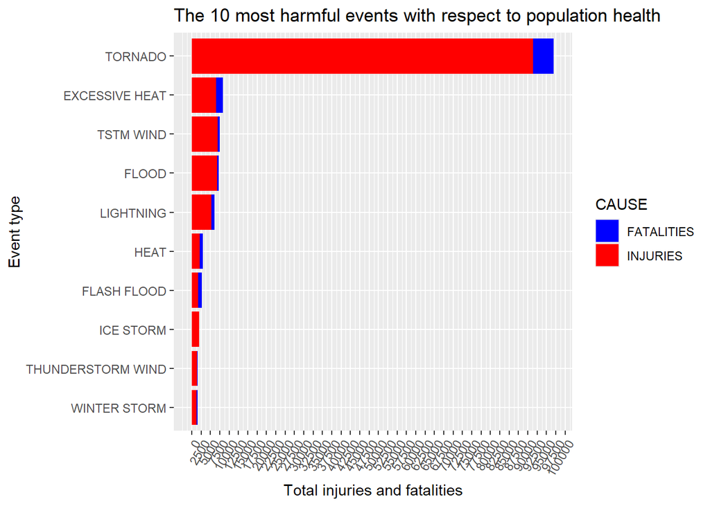

```r
ggplot(total_health_factor, aes(x = reorder(EVTYPE, COUNT), y = COUNT, fill = CAUSE)) +
  geom_bar(stat = "identity") + coord_flip() +
  scale_y_continuous(breaks = seq(0, 100000, by = 2500)) +
  ylab("Total injuries and fatalities") +
  xlab("Event type") +
  ggtitle("The 10 most harmful events with respect to population health") +
  theme(axis.text.x = element_text(angle = 60, hjust = 1))+
   scale_fill_manual(values = c("blue", "red"))
```

[figure not shown]

```r
ggplot(top_list, aes(x = reorder(EVTYPE, PROPDMG/10e9), y = PROPDMG/10e9)) +
  geom_col(fill = "darkred") +
  coord_flip() +
  labs(
    y = "Property damage in billions of dollars",
    x = "Event type",
    title = "The 10 most damaging events in terms of property damage"
  )
```